# Introduction

The problem we will be tackling today is a housing price regression. Given the features/amenities of a house, predict the price that the home sold for. Also, we will be participating in the "House Prices - Advanced Regression Techniques" competition on kaggle, however the main goal is to practice regressions rather than place well.

**What is a regression you might be asking yourself?**

A regression is a line of "best-fit" that tries to find predict a given features from other features in a dataset. For example, use the feature of house size to estimate/predict house cost.

There are 2 main types of regressions: logistic and linear

- A Linear regression tries to fit a simple line to the data, where X represents our input(s) and y represents our prediction.
- A logisitc regression tries to fit a sigmoid line to the data, where X represents our inputs(s) and y represents a class/type.

The line in a logistic regression the barrier between classes/types, while the line in a linear regression gives a number value.

We will be focused on using a linear regression since housing price is a number value and not a class or type.

# The Code

## Setup

```python
# Imports
import numpy as np
import pandas as pd
import seaborn as sns
import math as m
from matplotlib import pyplot as plt
```

```python
# Dataset setup
from google.colab import drive
drive.mount('/content/drive', force_remount=True)

import glob
import os

module_dir = '/content/drive/My Drive/Classes/Computer Science (General)/ITCS 3162/data/project_3'

train_path = os.path.join(module_dir, 'train.csv')
test_path = os.path.join(module_dir, 'test.csv')
desc_path = os.path.join(module_dir, 'data_description.txt')

df_train_orig = pd.read_csv(train_path)
df_test_orig = pd.read_csv(test_path)

data_desc = open(desc_path, "r")
```

```python
# Print Description of Features for dataset
print(data_desc.read())
```

```
MSSubClass: Identifies the type of dwelling involved in the sale.

        20	1-STORY 1946 & NEWER ALL STYLES
        30	1-STORY 1945 & OLDER
        40	1-STORY W/FINISHED ATTIC ALL AGES
        45	1-1/2 STORY - UNFINISHED ALL AGES
        50	1-1/2 STORY FINISHED ALL AGES
        60	2-STORY 1946 & NEWER
        70	2-STORY 1945 & OLDER
        75	2-1/2 STORY ALL AGES
        80	SPLIT OR MULTI-LEVEL
        85	SPLIT FOYER
        90	DUPLEX - ALL STYLES AND AGES
       120	1-STORY PUD (Planned Unit Development) - 1946 & NEWER
       150	1-1/2 STORY PUD - ALL AGES
       160	2-STORY PUD - 1946 & NEWER
       180	PUD - MULTILEVEL - INCL SPLIT LEV/FOYER
       190	2 FAMILY CONVERSION - ALL STYLES AND AGES

MSZoning: Identifies the general zoning classification of the sale.

       A	Agriculture
       C	Commercial
       FV	Floating Village Residential
       I	Industrial
       RH	Residential High Density
       RL	Residential Low Density
       RP	Residential Low Density Park
       RM	Residential Medium Density

LotFrontage: Linear feet of street connected to property

LotArea: Lot size in square feet

Street: Type of road access to property

       Grvl	Gravel
       Pave	Paved

Alley: Type of alley access to property
```

[output cut: 468 more lines]

```
       COD	Court Officer Deed/Estate
       Con	Contract 15% Down payment regular terms
       ConLw	Contract Low Down payment and low interest
       ConLI	Contract Low Interest
       ConLD	Contract Low Down
       Oth	Other

SaleCondition: Condition of sale

       Normal	Normal Sale
       Abnorml	Abnormal Sale -  trade, foreclosure, short sale
       AdjLand	Adjoining Land Purchase
       Alloca	Allocation - two linked properties with separate deeds, typically condo with a garage unit
       Family	Sale between family members
       Partial	Home was not completed when last assessed (associated with New Homes)
```

## Preprocessing

```python
# Before
df_train_orig.describe()
```

|  | Id | MSSubClass | LotFrontage | LotArea | OverallQual | OverallCond | YearBuilt | YearRemodAdd | MasVnrArea | BsmtFinSF1 | ... | WoodDeckSF | OpenPorchSF | EnclosedPorch | 3SsnPorch | ScreenPorch | PoolArea | MiscVal | MoSold | YrSold | SalePrice |
| --- | --- | --- | --- | --- | --- | --- | --- | --- | --- | --- | --- | --- | --- | --- | --- | --- | --- | --- | --- | --- | --- |
| count | 1460.000000 | 1460.000000 | 1201.000000 | 1460.000000 | 1460.000000 | 1460.000000 | 1460.000000 | 1460.000000 | 1452.000000 | 1460.000000 | ... | 1460.000000 | 1460.000000 | 1460.000000 | 1460.000000 | 1460.000000 | 1460.000000 | 1460.000000 | 1460.000000 | 1460.000000 | 1460.000000 |
| mean | 730.500000 | 56.897260 | 70.049958 | 10516.828082 | 6.099315 | 5.575342 | 1971.267808 | 1984.865753 | 103.685262 | 443.639726 | ... | 94.244521 | 46.660274 | 21.954110 | 3.409589 | 15.060959 | 2.758904 | 43.489041 | 6.321918 | 2007.815753 | 180921.195890 |
| std | 421.610009 | 42.300571 | 24.284752 | 9981.264932 | 1.382997 | 1.112799 | 30.202904 | 20.645407 | 181.066207 | 456.098091 | ... | 125.338794 | 66.256028 | 61.119149 | 29.317331 | 55.757415 | 40.177307 | 496.123024 | 2.703626 | 1.328095 | 79442.502883 |
| min | 1.000000 | 20.000000 | 21.000000 | 1300.000000 | 1.000000 | 1.000000 | 1872.000000 | 1950.000000 | 0.000000 | 0.000000 | ... | 0.000000 | 0.000000 | 0.000000 | 0.000000 | 0.000000 | 0.000000 | 0.000000 | 1.000000 | 2006.000000 | 34900.000000 |
| 25% | 365.750000 | 20.000000 | 59.000000 | 7553.500000 | 5.000000 | 5.000000 | 1954.000000 | 1967.000000 | 0.000000 | 0.000000 | ... | 0.000000 | 0.000000 | 0.000000 | 0.000000 | 0.000000 | 0.000000 | 0.000000 | 5.000000 | 2007.000000 | 129975.000000 |
| 50% | 730.500000 | 50.000000 | 69.000000 | 9478.500000 | 6.000000 | 5.000000 | 1973.000000 | 1994.000000 | 0.000000 | 383.500000 | ... | 0.000000 | 25.000000 | 0.000000 | 0.000000 | 0.000000 | 0.000000 | 0.000000 | 6.000000 | 2008.000000 | 163000.000000 |
| 75% | 1095.250000 | 70.000000 | 80.000000 | 11601.500000 | 7.000000 | 6.000000 | 2000.000000 | 2004.000000 | 166.000000 | 712.250000 | ... | 168.000000 | 68.000000 | 0.000000 | 0.000000 | 0.000000 | 0.000000 | 0.000000 | 8.000000 | 2009.000000 | 214000.000000 |
| max | 1460.000000 | 190.000000 | 313.000000 | 215245.000000 | 10.000000 | 9.000000 | 2010.000000 | 2010.000000 | 1600.000000 | 5644.000000 | ... | 857.000000 | 547.000000 | 552.000000 | 508.000000 | 480.000000 | 738.000000 | 15500.000000 | 12.000000 | 2010.000000 | 755000.000000 |

8 rows × 38 columns

```python
df_train_orig_types = df_train_orig.dtypes
for df_type in df_train_orig_types:
  print(df_type)
```

[output not shown]

[output cut: 26 more lines]

```
int64
int64
int64
int64
int64
int64
object
object
object
int64
int64
int64
object
object
int64
```

### Data Cleaning

```python
# Pre-process data imports
from sklearn.preprocessing import LabelEncoder, MinMaxScaler

# remove id column
df_train = df_train_orig.drop(['Id'], axis=1)

# Change categorical fields to numerical fields
label_encoder = LabelEncoder()

df_train_obj = df_train.select_dtypes("object")
df_train_nonobj = df_train.select_dtypes(exclude=['object'])

df_train_obj = df_train_obj.apply(LabelEncoder().fit_transform)

# mash together
df_train = pd.concat([df_train_obj, df_train_nonobj], axis=1)


df_train_types = df_train.dtypes
for df_type in df_train_types:
  print(df_type)

df_train.shape
```

[output not shown]

[output cut: 25 more lines]

```
int64
int64
float64
int64
int64
int64
int64
int64
int64
int64
int64
int64
int64
int64
int64
```

```
(1460, 80)
```

```python
print("Amount of Duplicates: %s\n" % (len(df_train_orig) - len(df_train_orig.drop_duplicates())))
print("Amount of Null Values:\n%s\n" % (df_train_orig.isna().sum()))
```

```
Amount of Duplicates: 0

Amount of Null Values:
Id                 0
MSSubClass         0
MSZoning           0
LotFrontage      259
LotArea            0
                ...
MoSold             0
YrSold             0
SaleType           0
SaleCondition      0
SalePrice          0
Length: 81, dtype: int64
```

```python
df_train = df_train.dropna()

df_train.shape
```

```
(1121, 80)
```

The shape is consistent with what we started with minus our nan values. It is important that we check the shape because we split the data apart and made modifications.

```python
df_train['Utilities'].nunique
```

```
<bound method IndexOpsMixin.nunique of 0       0
1       0
2       0
3       0
4       0
       ..
1455    0
1456    0
1457    0
1458    0
1459    0
Name: Utilities, Length: 1121, dtype: int64>
```

If we notice, the utilities value is constant for every property in our data. Let's drop it.

```python
df_train = df_train.drop(labels="Utilities", axis=1)
df_train.shape
```

```
(1121, 79)
```

Finally it is time to split our into our X and y (where the y is our SalePrice), and standardize our data between 0 and 1

```python
price_max = df_train['SalePrice'].to_numpy().max()
df_price = df_train['SalePrice']
df_train = df_train.drop(['SalePrice'], axis=1)

mm_scaler = MinMaxScaler()

col_names = list(df_train.columns)
df_mm = mm_scaler.fit_transform(df_train)
df_train = pd.DataFrame(df_mm, columns=col_names)

df_price = df_price.loc[:] / price_max
```

### Experiment Setup

After cleaning the data, we can finally experiment. Before experimenting, Let's look at our coorelations in terms of SalesPrice

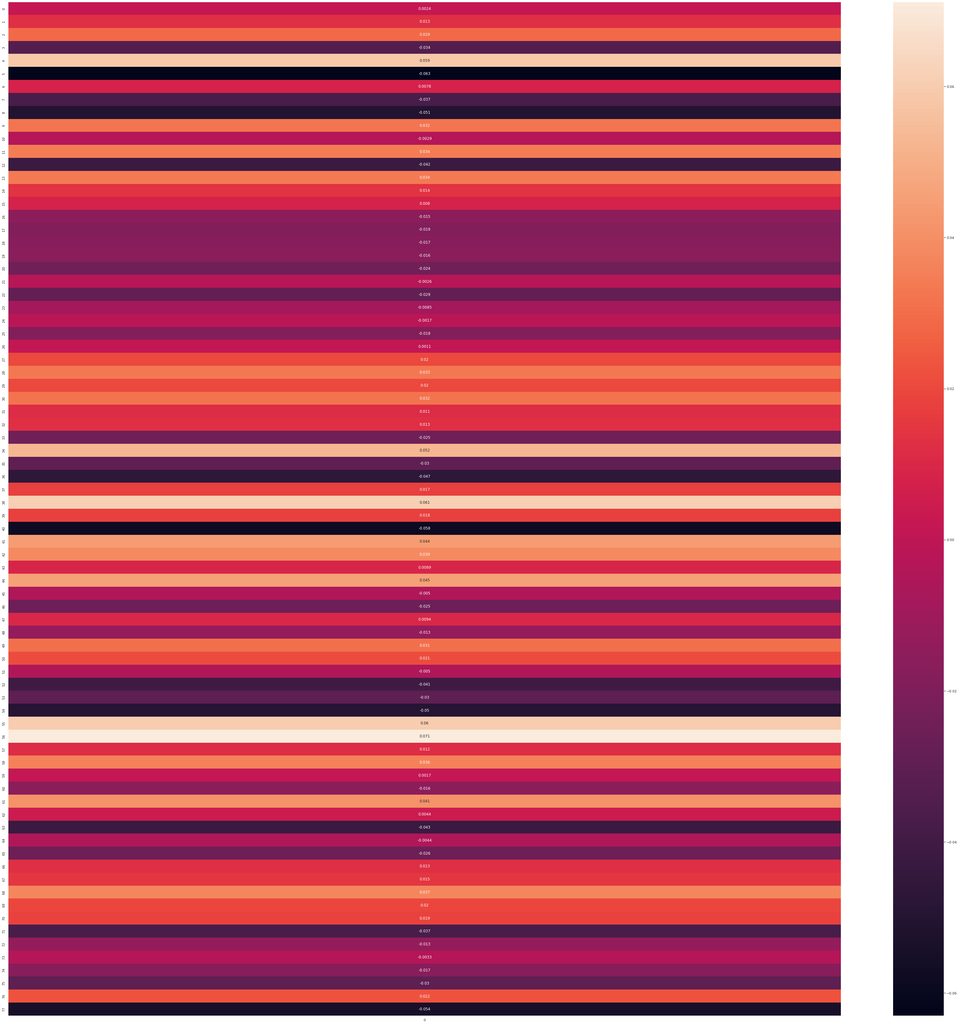

```python
# Print the coorelation marix
corr = df_train.corrwith(df_price, method='spearman') # Using Spearman
corr = np.asarray(corr).reshape(len(corr),1)
sns.set(rc = {'figure.figsize':(60,60)})
sns.heatmap(corr, annot=True)
```

```python
# Method for trimming out features we do not need
one_side_colnames = []
two_side_pos_colnames = []
two_side_neg_colnames = []

def compute_correlated_df(dataset, corr_matrix, threshold, method):
    col_corr = 0
    dataset_trimmed = pd.DataFrame()

    for i, val in enumerate(corr_matrix):
      if method == 'one_side':
        if (val < threshold):
          # getting the name of column
          colname = dataset.columns[i]
          one_side_colnames.append(colname)
          # if number of correlating columns 0 then create new DataFrame based on column found
          # else add new column to existing DataFrame
          if col_corr == 0:
            dataset_trimmed = dataset[colname]
          else:
            dataset_trimmed = pd.concat([dataset_trimmed, dataset[colname]], axis=1)
          col_corr += 1

      elif method == 'two_side_pos':
        if val >= threshold and val < 1:
          # getting the name of column
          colname = dataset.columns[i]
          two_side_pos_colnames.append(colname)
          # if number of correlating columns 0 then create new DataFrame based on column found
          # else add new column to existing DataFrame
          if col_corr == 0:
            dataset_trimmed = dataset[colname]
          else:
            dataset_trimmed = pd.concat([dataset_trimmed, dataset[colname]], axis=1)
          col_corr += 1

      elif method == 'two_side_neg':
        if val <= threshold and val > -1:
          # getting the name of column
          colname = dataset.columns[i]
          two_side_neg_colnames.append(colname)
          # if number of correlating columns 0 then create new DataFrame based on column found
          # else add new column to existing DataFrame
          if col_corr == 0:
            dataset_trimmed = dataset[colname]
          else:
            dataset_trimmed = pd.concat([dataset_trimmed, dataset[colname]], axis=1)
          col_corr += 1

      else:
        return dataset

    if col_corr == 0:
      return dataset
    else:
      return dataset_trimmed
```

```python
corr_abs = df_train.corrwith(df_price, method='spearman').abs()
corr_abs = np.asarray(corr_abs).reshape(len(corr_abs),1)

experiment_1 = compute_correlated_df(df_train, corr_abs, .04, 'one_side').to_numpy()
experiment_2 = compute_correlated_df(df_train, corr, .04, 'two_side_pos').to_numpy()
experiment_3 = compute_correlated_df(df_train, corr, -.04, 'two_side_neg').to_numpy()
```

```python
print('Experiment 1 Shape:')
print(experiment_1.shape)
print('\n')

print('Experiment 2 Shape:')
print(experiment_2.shape)
print('\n')

print('Experiment 3 Shape:')
print(experiment_3.shape)
print('\n')
```

```
Experiment 1 Shape:
(1121, 61)


Experiment 2 Shape:
(1121, 8)


Experiment 3 Shape:
(1121, 9)
```

## Modeling

Now that all of the data has been processed for our experiments, it is time to train a linear regression and see which is the best

```python
# imports
from sklearn import datasets, linear_model
import matplotlib.pyplot as plt

# create linear regression models
regr_1 = linear_model.LinearRegression()
regr_2 = linear_model.LinearRegression()
regr_3 = linear_model.LinearRegression()
```

```python
regr_1.fit(experiment_1, df_price)
regr_2.fit(experiment_2, df_price)
regr_3.fit(experiment_3, df_price)
```

```
LinearRegression()
```

```python
# The coefficients
print('EXPERIMENT 1 COEFFICIENTS:')
print('Coefficients: \n', regr_1.coef_)
print('Intercept: \n', regr_1.intercept_, '\n')

print('EXPERIMENT 2 COEFFICIENTS:')
print('Coefficients: \n', regr_2.coef_)
print('Intercept: \n', regr_2.intercept_, '\n')

print('EXPERIMENT 3 COEFFICIENTS:')
print('Coefficients: \n', regr_3.coef_)
print('Intercept: \n', regr_3.intercept_)
```

```
EXPERIMENT 1 COEFFICIENTS:
Coefficients:
 [-4.12619562e-03  5.47843548e-02  1.31664902e-02 -3.09045803e-03
  1.43616960e-02  1.65638853e-02 -9.42499287e-02 -1.91119706e-02
 -7.03965656e-03  6.28639665e-02 -1.47401177e-02  4.10813025e-03
  1.86418104e-02 -4.19939887e-02  6.51524891e-03  3.04377397e-04
 -4.56162605e-02  9.69154474e-03 -1.96403705e-02 -1.02526083e-02
  1.15973888e-02  2.77701757e-02 -3.30904502e-03  7.58000445e-03
  2.15874612e-04 -3.28597916e-02  2.72604502e-02 -8.31243955e-03
  1.63964121e-03 -6.89881626e-03  1.00286019e-02 -5.41547271e-01
  3.66607906e-04 -3.28236292e-02 -6.31463637e-02  1.21058413e-01
  5.16810343e-02  3.92983037e-02  1.63644662e-03  8.03551530e-02
  7.59010946e-02  3.76621521e-02  7.90348599e-03  3.09009009e-01
  1.25143224e-02 -1.18028874e-02  1.17381745e-02 -3.56481259e-02
  3.27179815e-02  1.62642168e-02 -1.51849333e-02  5.33415871e-02
  9.38329513e-03  2.04452835e-02 -3.90215517e-03 -1.81619174e-02
  2.57740215e-02  2.75342638e-02 -4.47555225e-01 -8.53555776e-03
 -5.26479131e-03]
Intercept:
 0.588079452749654

EXPERIMENT 2 COEFFICIENTS:
Coefficients:
 [0.02568411 0.07960129 0.04883348 0.09015805 0.78374192 0.11626163
 0.00163597 0.04171434]
Intercept:
 -0.02645398590606063

EXPERIMENT 3 COEFFICIENTS:
Coefficients:
 [-0.01226933  0.03303662  0.03050109  0.04129406  0.00173988  0.01756124
  0.69643132 -0.17421918 -0.00229582]
Intercept:
 0.07527316927284108
```

We can see that the more elements in our input we had, the more coefficients we had

## Evaluation

Time to test our linear regressions. First, we need to set up our test set data.

### Data Cleaning part 2

We need to do the same things we did above to our training for our test data

```python
# Change categorical fields to numerical fields
label_encoder = LabelEncoder()

df_test_obj = df_test_orig.select_dtypes("object")
df_test_nonobj = df_test_orig.select_dtypes(exclude=['object'])

df_test_obj = df_test_obj.apply(LabelEncoder().fit_transform)

# mash together
df_test = pd.concat([df_test_obj, df_test_nonobj], axis=1)


# standardize
col_names = list(df_test.columns)
df_mm = mm_scaler.fit_transform(df_test)
df_test = pd.DataFrame(df_mm, columns=col_names)
```

```python
# split up the test input for our linear regressions to work properly
# also convert everything to numpy arrays for easier testing
test_1 = df_test[one_side_colnames].to_numpy()
print(test_1.shape)

test_2 = df_test[two_side_pos_colnames].to_numpy()
print(test_2.shape)

test_3 = df_test[two_side_neg_colnames].to_numpy()
print(test_3.shape)
```

```
(1459, 61)
(1459, 8)
(1459, 9)
```

## Testing

According to the competition, there is no test y values available publically, so we will have to submit our code then view the root mean squared error from the competition.

```python
y_test_1_val = []
for i in range(test_1.shape[0]):
    y_test_1_val.append(regr_1.predict(test_1[i,:].reshape(1, -1)) * price_max)

y_test_1_val
```

[output not shown]

We get an error stating that there are NaN values, let's fill the NaN values with zeros and try again

```python
df_test = df_test.fillna(value=0.0, axis=1)

# split up the test input for our linear regressions to work properly
# also convert everything to numpy arrays for easier testing
test_1 = df_test[one_side_colnames].to_numpy()
print(test_1.shape)

test_2 = df_test[two_side_pos_colnames].to_numpy()
print(test_2.shape)

test_3 = df_test[two_side_neg_colnames].to_numpy()
print(test_3.shape)
```

```
(1459, 61)
(1459, 8)
(1459, 9)
```

```python
y_test_1_val = []
for i in range(test_1.shape[0]):
    y_test_1_val.append(regr_1.predict(test_1[i,:].reshape(1, -1)) * price_max)

len(y_test_1_val) # verfiy that we have starting number of datapoints
```

```
1459
```

It worked! Now we need to do that for the rest of our tests then submit for evaluation

```python
y_test_2_val = []
for i in range(test_2.shape[0]):
    y_test_2_val.append(regr_2.predict(test_2[i,:].reshape(1, -1)) * price_max)

len(y_test_2_val) # verfiy that we have starting number of datapoints
```

```
1459
```

```python
y_test_3_val = []
for i in range(test_3.shape[0]):
    y_test_3_val.append(regr_3.predict(test_3[i,:].reshape(1, -1)) * price_max)

len(y_test_3_val) # verfiy that we have starting number of datapoints
```

```
1459
```

```python
df_exp_1 = pd.DataFrame(y_test_1_val, columns=['SalePrice'])
df_exp_1 = pd.concat([df_test_orig['Id'], df_exp_1], axis=1)

df_exp_2 = pd.DataFrame(y_test_2_val, columns=['SalePrice'])
df_exp_2 = pd.concat([df_test_orig['Id'], df_exp_2], axis=1)

df_exp_3 = pd.DataFrame(y_test_3_val, columns=['SalePrice'])
df_exp_3 = pd.concat([df_test_orig['Id'], df_exp_3], axis=1)
```

```python
df_exp_1.to_csv(os.path.join(module_dir, 'exp_1.csv'), index=False) # Csv to be submitted to competition
```

```python
df_exp_2.to_csv(os.path.join(module_dir, 'exp_2.csv'), index=False) # Csv to be submitted to competition
```

```python
df_exp_3.to_csv(os.path.join(module_dir, 'exp_3.csv'), index=False) # Csv to be submitted to competition
```

## Results

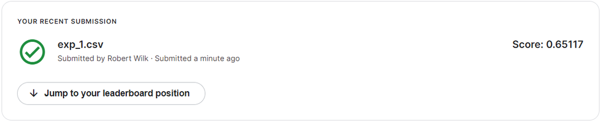

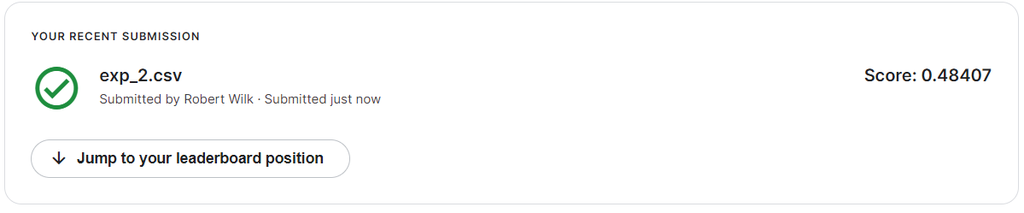

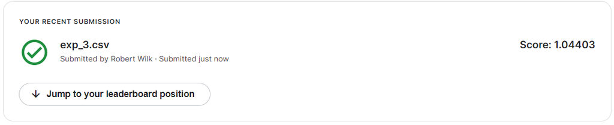

# Conclusion

**Sources:**

- [Source Code](https://colab.research.google.com/drive/1LzBqjpgkxL6d0aCvwofHbojTfwGGY7S5?usp=sharing)
- [Dataset](https://www.kaggle.com/c/house-prices-advanced-regression-techniques/overview)